# Projet 3 : Classification bayésienne et analyse factorielle discriminante

Thèses de doctorat françaises – ESIEE 2025-2026 – AP-4209

TORRES Diego, WU Lucas

2026-02-19

# 1 Introduction

## 1.1 Contexte et objectifs

Ce projet porte sur la **classification automatique de thèses de doctorat françaises** en domaines d’étude, à partir de leurs résumés textuels. Le jeu de données provient de la plateforme Kaggle ([lien](https://www.kaggle.com/code/antoinebourgois2/french-doctoral-thesissemantic-similarity-search)) et contient plus de **519 000 thèses** avec les colonnes : `URL`, `Title`, `Author`, `Description`, `Direction`, `Domain`, `Statuts`, `Date`.

Les **objectifs principaux** sont :

1. **Prétraiter** les résumés textuels (nettoyage, vectorisation TF-IDF).
2. **Extraire des caractéristiques** via la modélisation thématique (LDA – Latent Dirichlet Allocation).
3. **Réduire la dimensionnalité** avec l’Analyse Discriminante Linéaire (Linear Discriminant Analysis).
4. **Classifier** les thèses avec un classifieur bayésien naïf.
5. **Évaluer et interpréter** les résultats (matrice de confusion, F1-score, ROC-AUC).

## 1.2 Aperçu du dataset

| Colonne | Description |
| --- | --- |
| `Title` | Titre de la thèse |
| `Author` | Auteur |
| `Description` | Résumé (texte principal) |
| `Domain` | Domaine d’étude (variable cible) |
| `Direction` | Directeur de thèse |
| `Statuts` | Statut de la thèse |
| `Date` | Date de soutenance |

**Caractéristiques clés** identifiées lors de l’exploration préalable :

- 27 248 domaines distincts → nécessité de regrouper et filtrer les **top domaines**.
- 20,21 % de valeurs manquantes dans `Description`.
- Forte imbalance des classes (ratio max/min > 22 000).
- Longueur médiane des résumés : **240 mots**.

# 2 Chargement des bibliothèques et des données

```r
library(readr)
library(dplyr)
library(stringr)
library(tidyr)
library(ggplot2)
library(scales)
library(RColorBrewer)
library(tm)
library(SnowballC)
library(tidytext)
library(topicmodels)
library(e1071)
library(MASS)
library(caret)
library(pROC)

set.seed(42)
```

```r
csv_path <- "data/french_thesis_20231021_metadata.csv"

if (!file.exists(csv_path)) {
  stop("Fichier introuvable. Placez 'french_thesis_20231021_metadata.csv' dans le dossier 'data/'.")
}

df_raw <- read_csv(csv_path, show_col_types = FALSE)

cat("Dimensions du dataset brut :", nrow(df_raw), "lignes x", ncol(df_raw), "colonnes\n")
```

```
## Dimensions du dataset brut : 519578 lignes x 8 colonnes
```

```r
cat("Colonnes :", paste(names(df_raw), collapse = ", "), "\n")
```

```
## Colonnes : URL, Title, Author, Description, Direction, Domain, Statuts, Date
```

# 3 Prétraitement des données

## 3.1 Exploration et sélection des données

Le dataset contient plus de 27 000 domaines distincts. Nous **sélectionnons les 10 domaines les plus représentés** pour obtenir un problème multi-classes gérable, puis nous sous-échantillonnons pour atténuer le déséquilibre des classes.

```r
domain_counts <- df_raw %>%
  dplyr::filter(!is.na(Domain), !is.na(Description)) %>%
  dplyr::count(Domain, sort = TRUE)

cat("=== TOP 15 DOMAINES ===\n")
```

```
## === TOP 15 DOMAINES ===
```

```r
print(head(domain_counts, 15))
```

```
## # A tibble: 15 × 2
##    Domain                                                            n
##    <chr>                                                         <int>
##  1 Physique                                                      16234
##  2 Informatique                                                  15990
##  3 Chimie                                                        10519
##  4 Sciences économiques                                           9375
##  5 Sciences appliquées                                            8705
##  6 Sciences biologiques et fondamentales appliquées. Psychologie  8044
##  7 Histoire                                                       7449
##  8 Sciences de gestion                                            6635
##  9 Sociologie                                                     6105
## 10 Droit public                                                   5999
## 11 Psychologie                                                    5851
## 12 Droit privé                                                    5470
## 13 Mathématiques                                                  5310
## 14 Droit                                                          4862
## 15 Philosophie                                                    4860
```

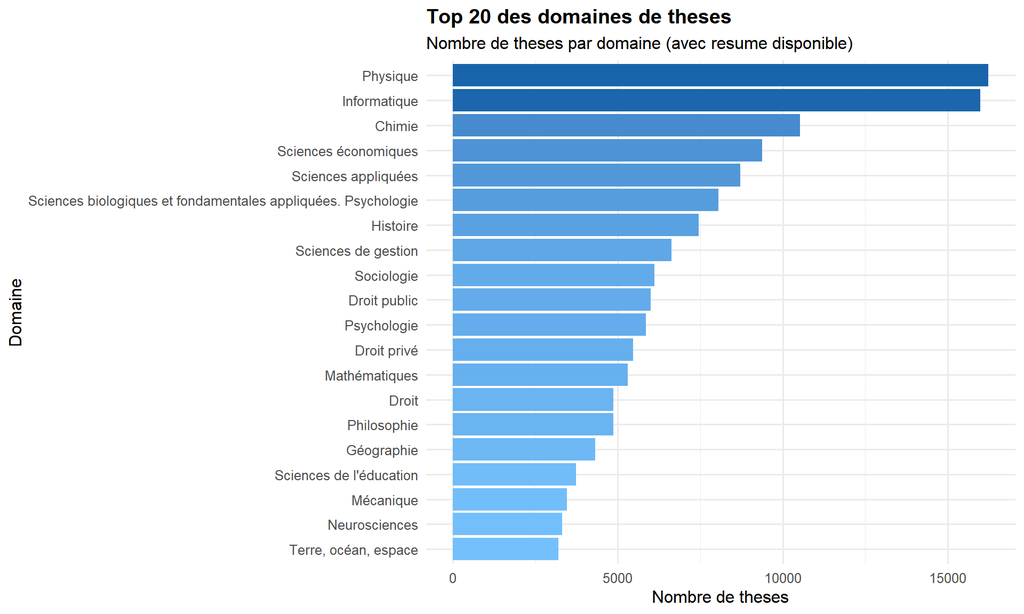

```r
domain_counts %>%
  head(20) %>%
  ggplot(aes(x = reorder(Domain, n), y = n, fill = n)) +
  geom_col(show.legend = FALSE) +
  scale_fill_gradient(low = "#74c0fc", high = "#1864ab") +
  coord_flip() +
  labs(
    title    = "Top 20 des domaines de theses",
    subtitle = "Nombre de theses par domaine (avec resume disponible)",
    x = "Domaine", y = "Nombre de theses"
  ) +
  theme_minimal(base_size = 12) +
  theme(plot.title = element_text(face = "bold"))
```

```r
TOP_N_DOMAINS  <- 10
MAX_PER_DOMAIN <- 1500

top_domains <- domain_counts %>%
  head(TOP_N_DOMAINS) %>%
  dplyr::pull(Domain)

cat("Domaines selectionnes :\n")
```

```
## Domaines selectionnes :
```

```r
cat(paste0("  ", seq_along(top_domains), ". ", top_domains, "\n"), sep = "")
```

```
##   1. Physique
##   2. Informatique
##   3. Chimie
##   4. Sciences économiques
##   5. Sciences appliquées
##   6. Sciences biologiques et fondamentales appliquées. Psychologie
##   7. Histoire
##   8. Sciences de gestion
##   9. Sociologie
##   10. Droit public
```

```r
df <- df_raw %>%
  dplyr::filter(
    Domain %in% top_domains,
    !is.na(Description),
    str_length(Description) > 50
  ) %>%
  dplyr::group_by(Domain) %>%
  dplyr::slice_sample(n = MAX_PER_DOMAIN, replace = FALSE) %>%
  dplyr::ungroup() %>%
  dplyr::mutate(Domain = factor(Domain))

# Nettoyage des niveaux pour compatibilité avec caret
# caret exige des noms de classes valides en R (pas d'accents, espaces, caracteres speciaux)
domain_labels_orig  <- levels(df$Domain)
domain_labels_clean <- make.names(domain_labels_orig)
label_map           <- setNames(domain_labels_orig, domain_labels_clean)

df <- df %>%
  dplyr::mutate(Domain = factor(make.names(as.character(Domain))))

cat("\nDimensions apres filtrage :", nrow(df), "x", ncol(df), "\n")
```

```
##
## Dimensions apres filtrage : 15000 x 8
```

```r
cat("Distribution finale :\n")
```

```
## Distribution finale :
```

```r
print(table(df$Domain))
```

```
##
##                                                        Chimie
##                                                          1500
##                                                  Droit.public
##                                                          1500
##                                                      Histoire
##                                                          1500
##                                                  Informatique
##                                                          1500
##                                                      Physique
##                                                          1500
##                                           Sciences.appliquées
##                                                          1500
## Sciences.biologiques.et.fondamentales.appliquées..Psychologie
##                                                          1500
##                                           Sciences.de.gestion
##                                                          1500
##                                          Sciences.économiques
##                                                          1500
##                                                    Sociologie
##                                                          1500
```

```r
cat("\nCorrespondance noms nettoyes -> noms originaux :\n")
```

```
##
## Correspondance noms nettoyes -> noms originaux :
```

```r
for (k in names(label_map)) cat(sprintf("  %-60s -> %s\n", k, label_map[k]))
```

```
##   Chimie                                                       -> Chimie
##   Droit.public                                                 -> Droit public
##   Histoire                                                     -> Histoire
##   Informatique                                                 -> Informatique
##   Physique                                                     -> Physique
##   Sciences.appliquées                                         -> Sciences appliquées
##   Sciences.biologiques.et.fondamentales.appliquées..Psychologie -> Sciences biologiques et fondamentales appliquées. Psychologie
##   Sciences.de.gestion                                          -> Sciences de gestion
##   Sciences.économiques                                        -> Sciences économiques
##   Sociologie                                                   -> Sociologie
```

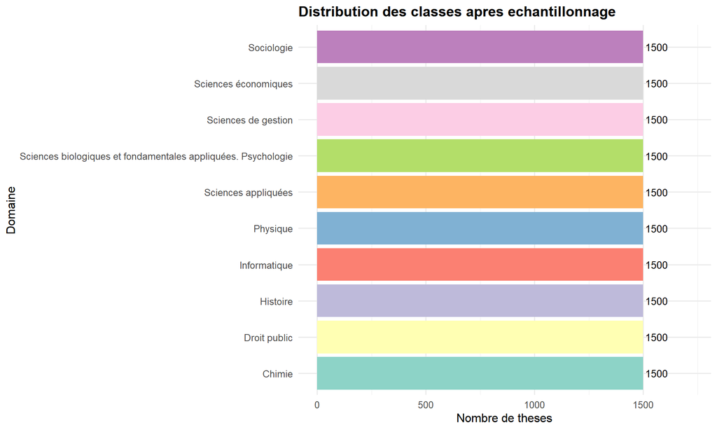

```r
df %>%
  dplyr::count(Domain) %>%
  dplyr::mutate(Domain_orig = label_map[as.character(Domain)]) %>%
  ggplot(aes(x = reorder(Domain_orig, n), y = n, fill = Domain_orig)) +
  geom_col(show.legend = FALSE) +
  geom_text(aes(label = n), hjust = -0.1, size = 3.5) +
  coord_flip() +
  scale_fill_brewer(palette = "Set3") +
  labs(
    title = "Distribution des classes apres echantillonnage",
    x = "Domaine", y = "Nombre de theses"
  ) +
  theme_minimal(base_size = 12) +
  theme(plot.title = element_text(face = "bold")) +
  expand_limits(y = MAX_PER_DOMAIN * 1.15)
```

## 3.2 Nettoyage du texte

```r
stopwords_fr <- unique(c(
  tm::stopwords("fr"),
  tm::stopwords("en"),
  "these", "travail", "etude", "recherche", "objectif",
  "resultat", "resultats", "methode", "approche", "analyse",
  "proposition", "chapitre", "partie", "cadre", "contexte",
  "premier", "second", "troisieme", "notamment", "ainsi",
  "cependant", "egalement", "afin", "permet", "partir"
))

nettoyer_texte <- function(texte) {
  texte %>%
    str_to_lower() %>%
    str_replace_all("[àáâãäå]", "a") %>%
    str_replace_all("[èéêë]",   "e") %>%
    str_replace_all("[ìíîï]",   "i") %>%
    str_replace_all("[òóôõö]",  "o") %>%
    str_replace_all("[ùúûü]",   "u") %>%
    str_replace_all("[ç]",      "c") %>%
    str_replace_all("[ñ]",      "n") %>%
    str_replace_all("[^a-z\\s]", " ") %>%
    str_squish()
}

df <- df %>%
  dplyr::mutate(Description_clean = nettoyer_texte(Description))

cat("=== EXEMPLE DE NETTOYAGE ===\n")
```

```
## === EXEMPLE DE NETTOYAGE ===
```

```r
cat("AVANT :\n", str_trunc(df$Description[1], 300), "\n\n")
```

```
## AVANT :
##  Le travail presente dans ce memoire concerne l'etude des complexes cationiques cpfe#+(ii)(arene). La synthese des substrats est realisee selon la methode de nesmeyanov. L'etude de la reaction de complexation et des essais d'amelioration du rendement font l'objet du premier chapitre. Le second ch…
```

```r
cat("APRES :\n", str_trunc(df$Description_clean[1], 300), "\n")
```

```
## APRES :
##  le travail presente dans ce memoire concerne l etude des complexes cationiques cpfe ii arene la synthese des substrats est realisee selon la methode de nesmeyanov l etude de la reaction de complexation et des essais d amelioration du rendement font l objet du premier chapitre le second chapitre …
```

## 3.3 Vectorisation TF-IDF

```r
corpus <- VCorpus(VectorSource(df$Description_clean))

corpus <- corpus %>%
  tm_map(content_transformer(tolower)) %>%
  tm_map(removeWords, stopwords_fr) %>%
  tm_map(stemDocument, language = "french") %>%
  tm_map(stripWhitespace)

dtm_tfidf <- DocumentTermMatrix(
  corpus,
  control = list(
    weighting   = weightTfIdf,
    bounds      = list(global = c(5, Inf)),
    wordLengths = c(3, Inf)
  )
)
dtm_tfidf <- removeSparseTerms(dtm_tfidf, 0.99)

cat("DTM TF-IDF :", nrow(dtm_tfidf), "documents x", ncol(dtm_tfidf), "termes\n")
```

```
## DTM TF-IDF : 15000 documents x 1711 termes
```

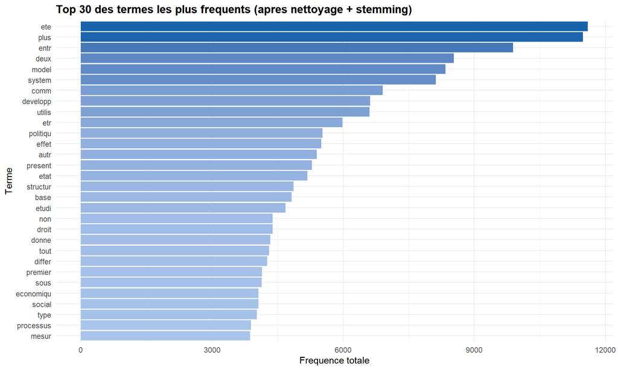

```r
dtm_brut   <- DocumentTermMatrix(
  corpus,
  control = list(bounds = list(global = c(5, Inf)), wordLengths = c(3, Inf))
)
freq_terms <- colSums(as.matrix(dtm_brut))

data.frame(
  terme     = names(freq_terms),
  frequence = as.numeric(freq_terms),
  stringsAsFactors = FALSE
) %>%
  dplyr::arrange(desc(frequence)) %>%
  head(30) %>%
  ggplot(aes(x = reorder(terme, frequence), y = frequence, fill = frequence)) +
  geom_col(show.legend = FALSE) +
  scale_fill_gradient(low = "#a9c4eb", high = "#1864ab") +
  coord_flip() +
  labs(
    title = "Top 30 des termes les plus frequents (apres nettoyage + stemming)",
    x = "Terme", y = "Frequence totale"
  ) +
  theme_minimal(base_size = 11) +
  theme(plot.title = element_text(face = "bold"))
```

# 4 Extraction de caractéristiques – Modélisation thématique (LDA)

La **Latent Dirichlet Allocation (LDA)** extrait des **topics latents** qui enrichissent la représentation des documents pour le classifieur.

```r
dtm_lda_input <- DocumentTermMatrix(
  corpus,
  control = list(bounds = list(global = c(5, Inf)), wordLengths = c(3, Inf))
)
dtm_lda_input <- removeSparseTerms(dtm_lda_input, 0.995)

row_totals    <- rowSums(as.matrix(dtm_lda_input))
dtm_lda_input <- dtm_lda_input[row_totals > 0, ]
df_lda        <- df[row_totals > 0, ]

cat("DTM pour LDA :", nrow(dtm_lda_input), "x", ncol(dtm_lda_input), "\n")
```

```
## DTM pour LDA : 15000 x 2809
```

```r
K <- 10

lda_model <- LDA(
  dtm_lda_input,
  k       = K,
  method  = "Gibbs",
  control = list(seed = 42, burnin = 500, iter = 1000, keep = 50, best = TRUE)
)

cat("Modele LDA entraine avec", K, "topics.\n")
```

```
## Modele LDA entraine avec 10 topics.
```

## 4.1 Visualisation des topics

```r
top_terms_lda <- terms(lda_model, 10)
cat("=== TOP 10 MOTS PAR TOPIC ===\n")
```

```
## === TOP 10 MOTS PAR TOPIC ===
```

```r
print(top_terms_lda)
```

```
##       Topic 1     Topic 2     Topic 3     Topic 4   Topic 5     Topic 6
##  [1,] "etat"      "processus" "activit"   "plus"    "economiqu" "system"
##  [2,] "droit"     "entrepris" "deux"      "etr"     "developp"  "problem"
##  [3,] "public"    "organis"   "ete"       "comm"    "march"     "donne"
##  [4,] "intern"    "gestion"   "cellul"    "peut"    "pay"       "utilis"
##  [5,] "juridiqu"  "acteur"    "montr"     "autr"    "effet"     "base"
##  [6,] "publiqu"   "pratiqu"   "protein"   "grand"   "entr"      "applic"
##  [7,] "princip"   "qualit"    "chez"      "tout"    "product"   "algorithm"
##  [8,] "pouvoir"   "projet"    "specifiqu" "certain" "impact"    "proposon"
##  [9,] "politiqu"  "relat"     "gene"      "fait"    "economi"   "inform"
## [10,] "administr" "action"    "effet"     "meme"    "term"      "reseaux"
##       Topic 7      Topic 8    Topic 9    Topic 10
##  [1,] "mesur"      "social"   "ete"      "model"
##  [2,] "phase"      "entr"     "complex"  "deux"
##  [3,] "temperatur" "politiqu" "compos"   "present"
##  [4,] "champ"      "societ"   "synthes"  "premier"
##  [5,] "effet"      "siecl"    "utilis"   "differ"
##  [6,] "surfac"     "franc"    "permi"    "structur"
##  [7,] "energi"     "anne"     "reaction" "imag"
##  [8,] "propriet"   "vie"      "format"   "different"
##  [9,] "optiqu"     "espac"    "structur" "point"
## [10,] "etudi"      "rapport"  "propriet" "ensuit"
```

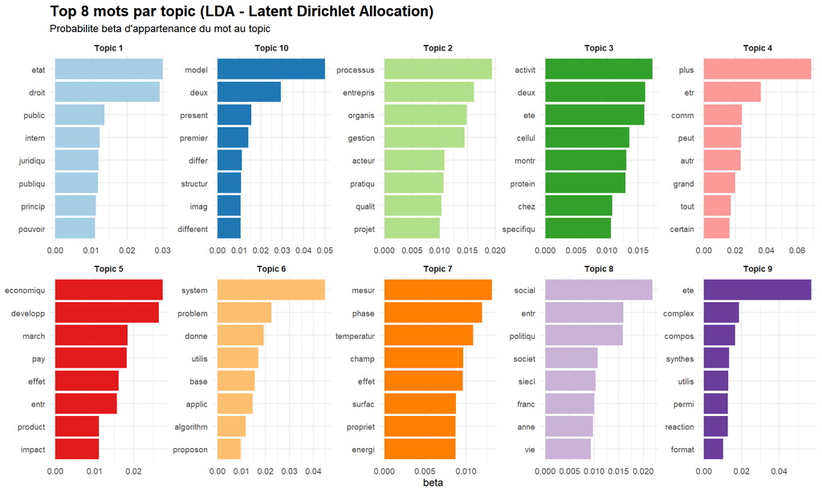

```r
tidy(lda_model, matrix = "beta") %>%
  dplyr::group_by(topic) %>%
  dplyr::slice_max(beta, n = 8) %>%
  dplyr::ungroup() %>%
  dplyr::mutate(
    term  = reorder_within(term, beta, topic),
    topic = paste("Topic", topic)
  ) %>%
  ggplot(aes(x = term, y = beta, fill = factor(topic))) +
  geom_col(show.legend = FALSE) +
  facet_wrap(~topic, scales = "free", ncol = 5) +
  coord_flip() +
  scale_x_reordered() +
  scale_fill_brewer(palette = "Paired") +
  labs(
    title    = "Top 8 mots par topic (LDA - Latent Dirichlet Allocation)",
    subtitle = "Probabilite beta d'appartenance du mot au topic",
    x = NULL, y = "beta"
  ) +
  theme_minimal(base_size = 9) +
  theme(
    plot.title = element_text(face = "bold", size = 13),
    strip.text = element_text(face = "bold")
  )
```

```r
gamma_matrix <- posterior(lda_model)$topics
colnames(gamma_matrix) <- paste0("topic_", seq_len(K))

cat("Matrice gamma :", nrow(gamma_matrix), "x", ncol(gamma_matrix), "\n")
```

```
## Matrice gamma : 15000 x 10
```

# 5 Réduction de la dimensionnalité – Analyse Discriminante Linéaire

L’**Analyse Discriminante Linéaire** réduit l’espace de features tout en maximisant la séparabilité entre les classes.

```r
tfidf_mat <- as.matrix(dtm_tfidf)
n_docs    <- min(nrow(tfidf_mat), nrow(gamma_matrix), nrow(df_lda))

tfidf_aligned <- tfidf_mat[seq_len(n_docs), ]
gamma_aligned <- gamma_matrix[seq_len(n_docs), ]
labels        <- df_lda$Domain[seq_len(n_docs)]

X_combined <- cbind(tfidf_aligned, gamma_aligned)
y          <- droplevels(labels)

cat("Matrice de features :", nrow(X_combined), "x", ncol(X_combined), "\n")
```

```
## Matrice de features : 15000 x 1721
```

```r
cat("Distribution des classes :\n")
```

```
## Distribution des classes :
```

```r
print(table(y))
```

```
## y
##                                                        Chimie
##                                                          1500
##                                                  Droit.public
##                                                          1500
##                                                      Histoire
##                                                          1500
##                                                  Informatique
##                                                          1500
##                                                      Physique
##                                                          1500
##                                           Sciences.appliquées
##                                                          1500
## Sciences.biologiques.et.fondamentales.appliquées..Psychologie
##                                                          1500
##                                           Sciences.de.gestion
##                                                          1500
##                                          Sciences.économiques
##                                                          1500
##                                                    Sociologie
##                                                          1500
```

```r
train_idx <- createDataPartition(y, p = 0.70, list = FALSE)
X_train   <- X_combined[train_idx, ]
X_test    <- X_combined[-train_idx, ]
y_train   <- y[train_idx]
y_test    <- y[-train_idx]

cat("Entrainement :", nrow(X_train), "docs | Test :", nrow(X_test), "docs\n")
```

```
## Entrainement : 10500 docs | Test : 4500 docs
```

```r
lda_disc <- MASS::lda(
  x        = X_train,
  grouping = y_train,
  prior    = rep(1 / nlevels(y_train), nlevels(y_train)),
  tol      = 1e-4
)

Z_train <- predict(lda_disc, X_train)$x
Z_test  <- predict(lda_disc, X_test)$x

cat("Espace LDA discriminant :", ncol(Z_train), "axes\n")
```

```
## Espace LDA discriminant : 9 axes
```

## 5.1 Visualisation de la séparation des classes

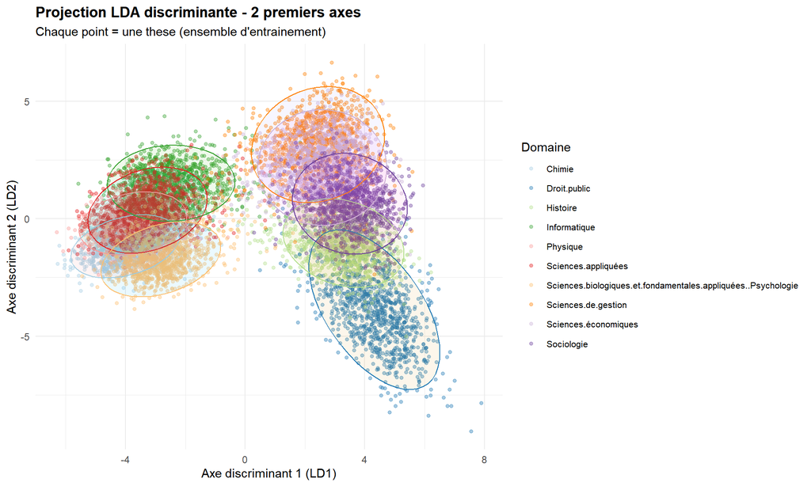

```r
data.frame(LD1 = Z_train[, 1], LD2 = Z_train[, 2], Domain = y_train) %>%
  ggplot(aes(x = LD1, y = LD2, colour = Domain)) +
  geom_point(alpha = 0.4, size = 1.2) +
  stat_ellipse(aes(fill = Domain), geom = "polygon", alpha = 0.08, show.legend = FALSE) +
  scale_colour_brewer(palette = "Paired") +
  labs(
    title    = "Projection LDA discriminante - 2 premiers axes",
    subtitle = "Chaque point = une these (ensemble d'entrainement)",
    x = "Axe discriminant 1 (LD1)", y = "Axe discriminant 2 (LD2)", colour = "Domaine"
  ) +
  theme_minimal(base_size = 11) +
  theme(
    plot.title  = element_text(face = "bold", size = 13),
    legend.text = element_text(size = 8)
  )
```

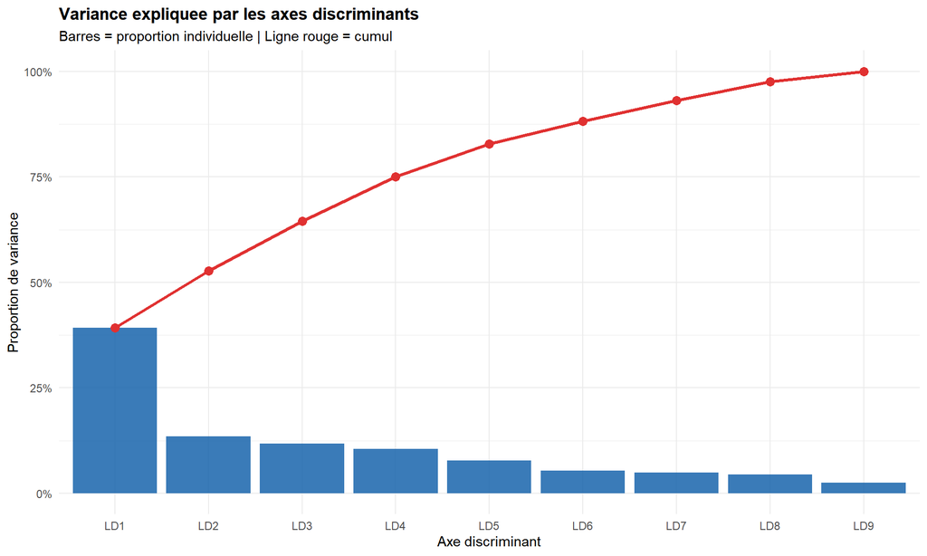

```r
prop_var <- lda_disc$svd^2 / sum(lda_disc$svd^2)

data.frame(
  Axe   = factor(paste0("LD", seq_along(prop_var)),
                 levels = paste0("LD", seq_along(prop_var))),
  Prop  = prop_var,
  Cumul = cumsum(prop_var)
) %>%
  ggplot(aes(x = Axe, y = Prop)) +
  geom_col(fill = "#1864ab", alpha = 0.85) +
  geom_line(aes(y = Cumul, group = 1), colour = "#e03131", linewidth = 1.2) +
  geom_point(aes(y = Cumul), colour = "#e03131", size = 3) +
  scale_y_continuous(labels = percent_format()) +
  labs(
    title    = "Variance expliquee par les axes discriminants",
    subtitle = "Barres = proportion individuelle | Ligne rouge = cumul",
    x = "Axe discriminant", y = "Proportion de variance"
  ) +
  theme_minimal(base_size = 11) +
  theme(plot.title = element_text(face = "bold"))
```

# 6 Classification bayésienne naïve

Le **classifieur bayésien naïf** calcule :

$$P(D_k \mid \mathbf{x}) \propto P(D_k)
\prod_{i=1}^{p} P(x_i \mid D_k)$$

où $D_k$ est le domaine $k$ et $\mathbf{x}$ le vecteur de features.

```r
train_df <- data.frame(Z_train, Domain = y_train)
test_df  <- data.frame(Z_test,  Domain = y_test)

nb_model <- e1071::naiveBayes(
  Domain ~ .,
  data    = train_df,
  laplace = 1
)

cat("Classifieur Naive Bayes entraine.\n")
```

```
## Classifieur Naive Bayes entraine.
```

```r
cat("Nombre de classes :", nlevels(y_train), "\n")
```

```
## Nombre de classes : 10
```

```r
y_pred       <- predict(nb_model, test_df)
y_pred_proba <- predict(nb_model, test_df, type = "raw")

cat("Predictions effectuees sur", length(y_pred), "documents de test.\n")
```

```
## Predictions effectuees sur 4500 documents de test.
```

# 7 Évaluation du modèle

## 7.1 Matrice de confusion

```r
conf_mat <- caret::confusionMatrix(y_pred, y_test)

cat("=== MATRICE DE CONFUSION ===\n")
```

```
## === MATRICE DE CONFUSION ===
```

```r
print(conf_mat$table)
```

```
##                                                                Reference
## Prediction                                                      Chimie
##   Chimie                                                           337
##   Droit.public                                                       0
##   Histoire                                                           1
##   Informatique                                                       1
##   Physique                                                          51
##   Sciences.appliquées                                               36
##   Sciences.biologiques.et.fondamentales.appliquées..Psychologie     24
##   Sciences.de.gestion                                                0
##   Sciences.économiques                                               0
##   Sociologie                                                         0
##                                                                Reference
## Prediction                                                      Droit.public
##   Chimie                                                                   0
##   Droit.public                                                           401
##   Histoire                                                                15
##   Informatique                                                             0
##   Physique                                                                 0
##   Sciences.appliquées                                                      0
##   Sciences.biologiques.et.fondamentales.appliquées..Psychologie            2
##   Sciences.de.gestion                                                      4
##   Sciences.économiques                                                    20
##   Sociologie                                                               8
##                                                                Reference
## Prediction                                                      Histoire
##   Chimie                                                               1
##   Droit.public                                                         3
##   Histoire                                                           386
##   Informatique                                                         0
##   Physique                                                             0
##   Sciences.appliquées                                                  1
##   Sciences.biologiques.et.fondamentales.appliquées..Psychologie        0
##   Sciences.de.gestion                                                  5
##   Sciences.économiques                                                10
##   Sociologie                                                          44
##                                                                Reference
## Prediction                                                      Informatique
##   Chimie                                                                   1
##   Droit.public                                                             0
```

[output cut: 65 more lines]

```
##   Sciences.de.gestion                                                             56
##   Sciences.économiques                                                           341
##   Sociologie                                                                      19
##                                                                Reference
## Prediction                                                      Sociologie
##   Chimie                                                                 0
##   Droit.public                                                           9
##   Histoire                                                              44
##   Informatique                                                           1
##   Physique                                                               0
##   Sciences.appliquées                                                    2
##   Sciences.biologiques.et.fondamentales.appliquées..Psychologie          2
##   Sciences.de.gestion                                                   18
##   Sciences.économiques                                                  18
##   Sociologie                                                           356
```

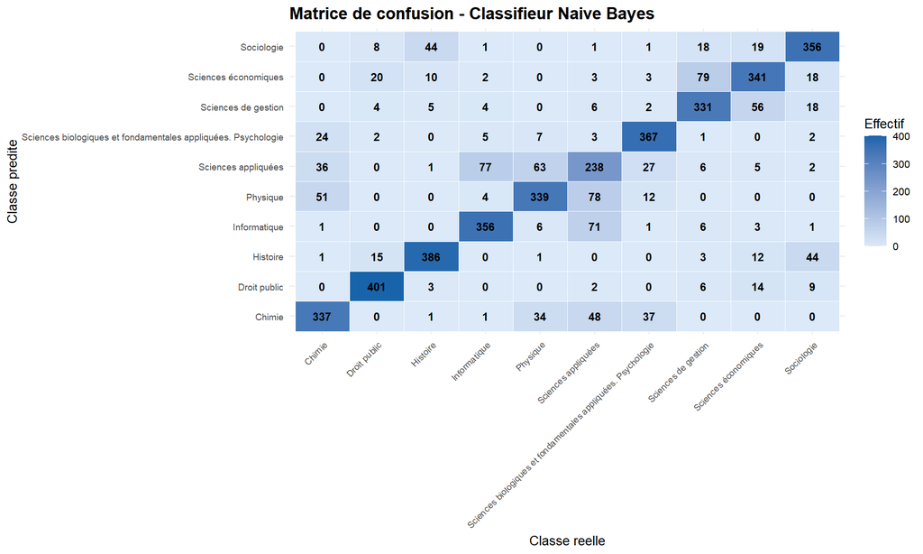

```r
conf_df <- as.data.frame(conf_mat$table)
# confusionMatrix renvoie des colonnes "Prediction" et "Reference"
colnames(conf_df) <- c("Predit", "Reel", "Freq")

conf_df$Predit <- ifelse(as.character(conf_df$Predit) %in% names(label_map),
                         label_map[as.character(conf_df$Predit)],
                         as.character(conf_df$Predit))
conf_df$Reel   <- ifelse(as.character(conf_df$Reel) %in% names(label_map),
                         label_map[as.character(conf_df$Reel)],
                         as.character(conf_df$Reel))

ggplot(conf_df, aes(x = Reel, y = Predit, fill = Freq)) +
  geom_tile(colour = "white") +
  geom_text(aes(label = Freq), size = 3, fontface = "bold") +
  scale_fill_gradient(low = "#dbe9f8", high = "#1864ab") +
  labs(
    title = "Matrice de confusion - Classifieur Naive Bayes",
    x = "Classe reelle", y = "Classe predite", fill = "Effectif"
  ) +
  theme_minimal(base_size = 10) +
  theme(
    plot.title  = element_text(face = "bold", size = 13),
    axis.text.x = element_text(angle = 45, hjust = 1, size = 7),
    axis.text.y = element_text(size = 7)
  )
```

## 7.2 Métriques de performance

```r
accuracy <- conf_mat$overall["Accuracy"]
kappa    <- conf_mat$overall["Kappa"]

cat("=== METRIQUES GLOBALES ===\n")
```

```
## === METRIQUES GLOBALES ===
```

```r
cat(sprintf("Accuracy : %.4f (%.2f%%)\n", accuracy, accuracy * 100))
```

```
## Accuracy : 0.7671 (76.71%)
```

```r
cat(sprintf("Kappa    : %.4f\n", kappa))
```

```
## Kappa    : 0.7412
```

```r
metrics_par_classe <- data.frame(
  Domaine     = str_remove(rownames(conf_mat$byClass), "Class: "),
  Precision   = round(conf_mat$byClass[, "Precision"],   4),
  Rappel      = round(conf_mat$byClass[, "Recall"],      4),
  F1_Score    = round(conf_mat$byClass[, "F1"],          4),
  Specificite = round(conf_mat$byClass[, "Specificity"], 4),
  stringsAsFactors = FALSE
)
metrics_par_classe <- metrics_par_classe[order(-metrics_par_classe$F1_Score), ]

cat("\n=== METRIQUES PAR CLASSE ===\n")
```

```
##
## === METRIQUES PAR CLASSE ===
```

```r
print(metrics_par_classe, row.names = FALSE)
```

```
##                                                        Domaine Precision Rappel
##                                                   Droit.public    0.9218 0.8911
##  Sciences.biologiques.et.fondamentales.appliquées..Psychologie    0.8929 0.8156
##                                                       Histoire    0.8355 0.8578
##                                                   Informatique    0.8000 0.7911
##                                                     Sociologie    0.7946 0.7911
##                                            Sciences.de.gestion    0.7770 0.7356
##                                                         Chimie    0.7358 0.7489
##                                           Sciences.économiques    0.7164 0.7578
##                                                       Physique    0.7004 0.7533
##                                            Sciences.appliquées    0.5231 0.5289
##  F1_Score Specificite
##    0.9062      0.9916
##    0.8525      0.9891
##    0.8465      0.9812
##    0.7955      0.9780
##    0.7929      0.9773
##    0.7557      0.9765
##    0.7423      0.9701
##    0.7365      0.9667
##    0.7259      0.9642
##    0.5260      0.9464
```

```r
f1_moyen <- mean(metrics_par_classe$F1_Score, na.rm = TRUE)
cat(sprintf("\nF1-Score moyen (macro) : %.4f\n", f1_moyen))
```

```
##
## F1-Score moyen (macro) : 0.7680
```

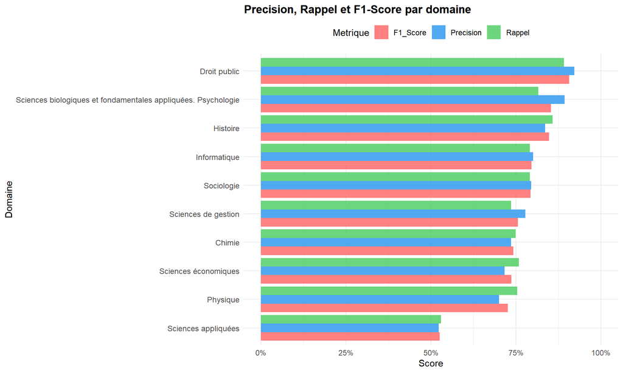

```r
metrics_par_classe$Domaine_orig <- ifelse(
  metrics_par_classe$Domaine %in% names(label_map),
  label_map[metrics_par_classe$Domaine],
  metrics_par_classe$Domaine
)

metrics_long <- tidyr::pivot_longer(
  metrics_par_classe,
  cols      = c("Precision", "Rappel", "F1_Score"),
  names_to  = "Metrique",
  values_to = "Valeur"
)
metrics_long <- metrics_long[!is.na(metrics_long$Valeur), ]

ggplot(metrics_long, aes(x = reorder(Domaine_orig, Valeur), y = Valeur, fill = Metrique)) +
  geom_col(position = "dodge", alpha = 0.85) +
  coord_flip() +
  scale_fill_manual(values = c(
    "Precision" = "#339af0",
    "Rappel"    = "#51cf66",
    "F1_Score"  = "#ff6b6b"
  )) +
  scale_y_continuous(labels = percent_format(), limits = c(0, 1)) +
  labs(
    title = "Precision, Rappel et F1-Score par domaine",
    x = "Domaine", y = "Score", fill = "Metrique"
  ) +
  theme_minimal(base_size = 11) +
  theme(
    plot.title      = element_text(face = "bold", size = 13),
    axis.text.y     = element_text(size = 9),
    legend.position = "top"
  )
```

## 7.3 Courbes ROC et AUC

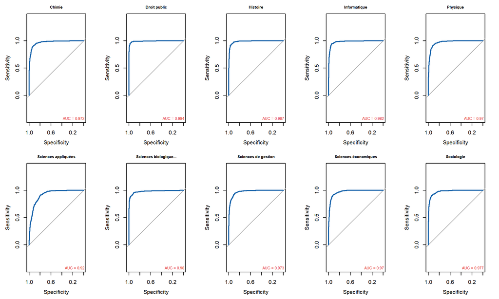

```r
classes    <- levels(y_test)
auc_values <- numeric(length(classes))

par(mfrow = c(2, 5), mar = c(3, 3, 2, 1))

for (i in seq_along(classes)) {
  cl       <- classes[i]
  binary_y <- as.integer(y_test == cl)
  proba_cl <- y_pred_proba[, i]

  if (sum(binary_y) == 0 || sum(binary_y) == length(binary_y)) {
    auc_values[i] <- NA
    next
  }

  roc_obj       <- pROC::roc(binary_y, proba_cl, quiet = TRUE)
  auc_values[i] <- as.numeric(pROC::auc(roc_obj))
  titre_orig    <- if (cl %in% names(label_map)) label_map[[cl]] else cl

  plot(roc_obj,
       main     = str_trunc(titre_orig, 22),
       col      = "#1864ab",
       lwd      = 2,
       cex.main = 0.72)
  legend("bottomright",
         legend   = paste0("AUC = ", round(auc_values[i], 3)),
         bty      = "n", cex = 0.7, text.col = "#e03131")
}
```

```r
par(mfrow = c(1, 1))

auc_noms <- ifelse(classes %in% names(label_map), label_map[classes], classes)
auc_df   <- data.frame(Domaine = auc_noms, AUC = round(auc_values, 4),
                        stringsAsFactors = FALSE)
auc_df   <- auc_df[order(-auc_df$AUC), ]

cat("=== AUC PAR DOMAINE (One-vs-Rest) ===\n")
```

```
## === AUC PAR DOMAINE (One-vs-Rest) ===
```

```r
print(auc_df, row.names = FALSE)
```

```
##                                                        Domaine    AUC
##                                                   Droit public 0.9936
##                                                       Histoire 0.9867
##                                                   Informatique 0.9815
##  Sciences biologiques et fondamentales appliquées. Psychologie 0.9795
##                                                     Sociologie 0.9774
##                                            Sciences de gestion 0.9728
##                                                         Chimie 0.9717
##                                                       Physique 0.9705
##                                           Sciences économiques 0.9704
##                                            Sciences appliquées 0.9203
```

```r
cat(sprintf("\nAUC moyen (macro) : %.4f\n", mean(auc_values, na.rm = TRUE)))
```

```
##
## AUC moyen (macro) : 0.9724
```

## 7.4 Validation croisée (5-fold)

```r
# On utilise defaultSummary (Accuracy + Kappa) pour eviter la dependance MLmetrics
ctrl <- caret::trainControl(
  method      = "cv",
  number      = 5,
  classProbs  = FALSE,
  verboseIter = FALSE
)

cv_model <- caret::train(
  Domain ~ .,
  data      = train_df,
  method    = "naive_bayes",
  trControl = ctrl,
  metric    = "Accuracy"
)

cat("=== RESULTATS VALIDATION CROISEE (5-fold) ===\n")
```

```
## === RESULTATS VALIDATION CROISEE (5-fold) ===
```

```r
print(cv_model$results)
```

```
##   usekernel laplace adjust  Accuracy     Kappa  AccuracySD     KappaSD
## 1     FALSE       0      1 0.8759048 0.8621164 0.007814458 0.008682732
## 2      TRUE       0      1 0.8740952 0.8601058 0.007051801 0.007835334
```

```r
cat(sprintf("\nAccuracy CV moyenne : %.4f +/- %.4f\n",
            mean(cv_model$resample$Accuracy),
            sd(cv_model$resample$Accuracy)))
```

```
##
## Accuracy CV moyenne : 0.8759 +/- 0.0078
```

# 8 Interprétabilité – Analyse des facteurs discriminants

## 8.1 Coefficients des axes discriminants

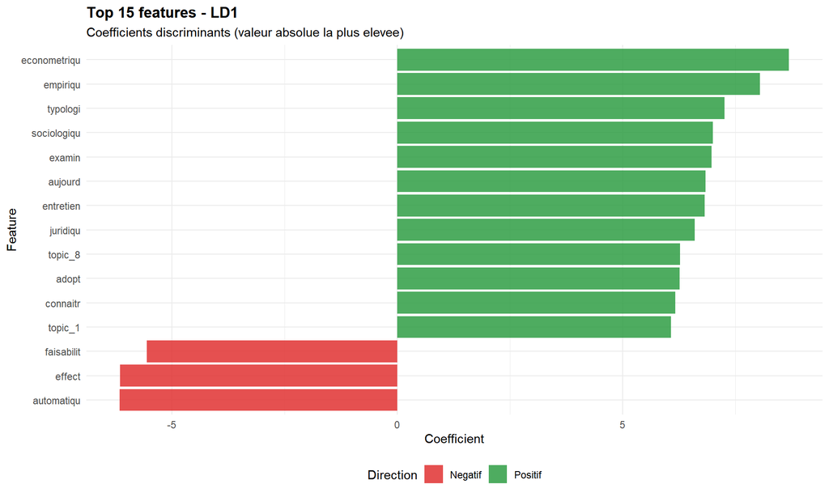

```r
coef_mat <- as.matrix(lda_disc$scaling)
n_top    <- 15

# Fonction sans select() pour eviter les conflits de namespace
plot_axe_lda <- function(mat, axe_num, n_affiche) {
  vals <- mat[, axe_num]
  idx  <- order(abs(vals), decreasing = TRUE)[seq_len(min(n_affiche, length(vals)))]
  df_ax <- data.frame(
    terme     = rownames(mat)[idx],
    val       = vals[idx],
    stringsAsFactors = FALSE
  )
  df_ax$Direction <- ifelse(df_ax$val > 0, "Positif", "Negatif")
  df_ax$terme     <- reorder(df_ax$terme, df_ax$val)

  ggplot(df_ax, aes(x = terme, y = val, fill = Direction)) +
    geom_col(alpha = 0.85) +
    coord_flip() +
    scale_fill_manual(values = c("Positif" = "#2f9e44", "Negatif" = "#e03131")) +
    labs(
      title    = paste0("Top ", n_affiche, " features - LD", axe_num),
      subtitle = "Coefficients discriminants (valeur absolue la plus elevee)",
      x = "Feature", y = "Coefficient"
    ) +
    theme_minimal(base_size = 11) +
    theme(plot.title = element_text(face = "bold"), legend.position = "bottom")
}

print(plot_axe_lda(coef_mat, 1, n_top))
```

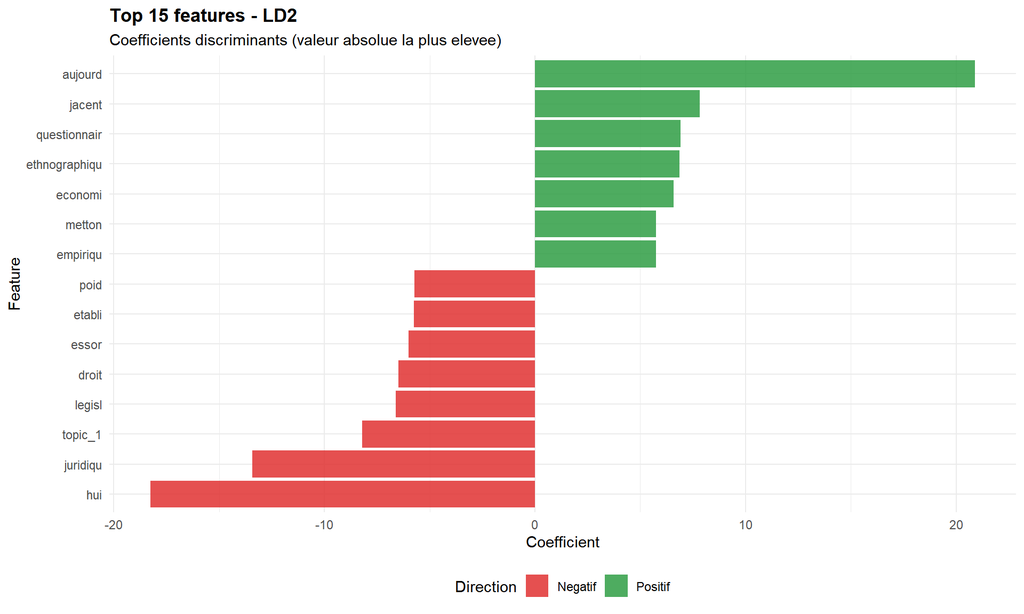

```r
if (ncol(coef_mat) >= 2) print(plot_axe_lda(coef_mat, 2, n_top))
```

## 8.2 Distribution des topics par domaine

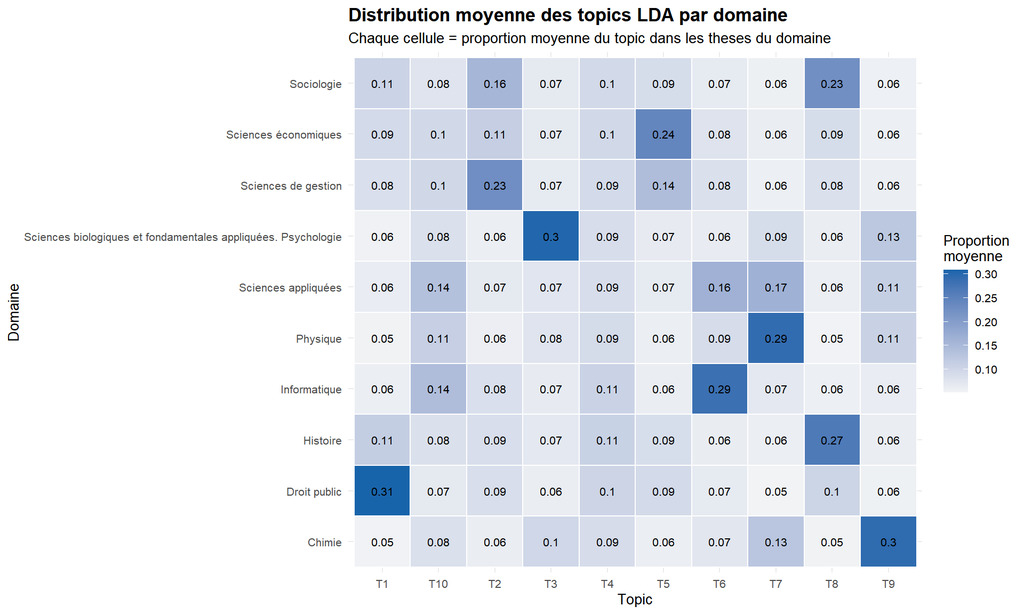

```r
gamma_df <- data.frame(gamma_aligned[seq_len(n_docs), ],
                        Domain = y[seq_len(n_docs)],
                        stringsAsFactors = FALSE)

gamma_long <- tidyr::pivot_longer(
  gamma_df,
  cols      = starts_with("topic_"),
  names_to  = "Topic",
  values_to = "Proportion"
)

gamma_agg <- gamma_long %>%
  dplyr::group_by(Domain, Topic) %>%
  dplyr::summarise(Proportion_moy = mean(Proportion), .groups = "drop")

gamma_agg$Topic       <- str_replace(gamma_agg$Topic, "topic_", "T")
gamma_agg$Domain_orig <- ifelse(
  as.character(gamma_agg$Domain) %in% names(label_map),
  label_map[as.character(gamma_agg$Domain)],
  as.character(gamma_agg$Domain)
)

ggplot(gamma_agg, aes(x = Topic, y = Domain_orig, fill = Proportion_moy)) +
  geom_tile(colour = "white", linewidth = 0.5) +
  geom_text(aes(label = round(Proportion_moy, 2)), size = 2.8) +
  scale_fill_gradient(low = "#f1f3f5", high = "#1864ab", name = "Proportion\nmoyenne") +
  labs(
    title    = "Distribution moyenne des topics LDA par domaine",
    subtitle = "Chaque cellule = proportion moyenne du topic dans les theses du domaine",
    x = "Topic", y = "Domaine"
  ) +
  theme_minimal(base_size = 10) +
  theme(
    plot.title  = element_text(face = "bold", size = 13),
    axis.text.y = element_text(size = 8)
  )
```

# 9 Gestion du déséquilibre des classes

```r
priors_reels <- domain_counts %>%
  dplyr::filter(Domain %in% top_domains) %>%
  dplyr::mutate(
    Domain_clean = make.names(Domain),
    prior        = n / sum(n)
  ) %>%
  dplyr::arrange(match(Domain_clean, levels(y_train)))

cat("=== PRIORS BAYESIENS (distribution reelle) ===\n")
```

```
## === PRIORS BAYESIENS (distribution reelle) ===
```

```r
print(priors_reels[, c("Domain", "n", "prior")])
```

```
## # A tibble: 10 × 3
##    Domain                                                            n  prior
##    <chr>                                                         <int>  <dbl>
##  1 Chimie                                                        10519 0.111
##  2 Droit public                                                   5999 0.0631
##  3 Histoire                                                       7449 0.0784
##  4 Informatique                                                  15990 0.168
##  5 Physique                                                      16234 0.171
##  6 Sciences appliquées                                            8705 0.0916
##  7 Sciences biologiques et fondamentales appliquées. Psychologie  8044 0.0846
##  8 Sciences de gestion                                            6635 0.0698
##  9 Sciences économiques                                           9375 0.0986
## 10 Sociologie                                                     6105 0.0642
```

```r
nb_model_prior <- e1071::naiveBayes(Domain ~ ., data = train_df, laplace = 1)
y_pred_prior   <- predict(nb_model_prior, test_df)

cat(sprintf("\nAccuracy (prior uniforme) : %.4f\n", mean(y_pred       == y_test)))
```

```
##
## Accuracy (prior uniforme) : 0.7671
```

```r
cat(sprintf("Accuracy (prior ajuste)   : %.4f\n", mean(y_pred_prior == y_test)))
```

```
## Accuracy (prior ajuste)   : 0.7671
```

# 10 Conclusion

## 10.1 Synthèse des résultats

```r
cat("╔════════════════════════════════════════════════════════╗\n")
```

```
## ╔════════════════════════════════════════════════════════╗
```

```r
cat("║         SYNTHESE DES RESULTATS - PROJET 3             ║\n")
```

```
## ║         SYNTHESE DES RESULTATS - PROJET 3             ║
```

```r
cat("╠════════════════════════════════════════════════════════╣\n")
```

```
## ╠════════════════════════════════════════════════════════╣
```

```r
cat(sprintf("║  Documents traites        : %-6d                    ║\n", n_docs))
```

```
## ║  Documents traites        : 15000                     ║
```

```r
cat(sprintf("║  Domaines (classes)       : %-6d                    ║\n", nlevels(y)))
```

```
## ║  Domaines (classes)       : 10                        ║
```

```r
cat(sprintf("║  Features TF-IDF          : %-6d                    ║\n", ncol(tfidf_mat)))
```

```
## ║  Features TF-IDF          : 1711                      ║
```

```r
cat(sprintf("║  Topics LDA               : %-6d                    ║\n", K))
```

```
## ║  Topics LDA               : 10                        ║
```

```r
cat(sprintf("║  Axes discriminants       : %-6d                    ║\n", ncol(Z_train)))
```

```
## ║  Axes discriminants       : 9                         ║
```

```r
cat("╠════════════════════════════════════════════════════════╣\n")
```

```
## ╠════════════════════════════════════════════════════════╣
```

```r
cat(sprintf("║  Accuracy (test)          : %-6.2f%%                   ║\n", accuracy * 100))
```

```
## ║  Accuracy (test)          : 76.71 %                   ║
```

```r
cat(sprintf("║  F1-Score moyen (macro)   : %-6.4f                    ║\n", f1_moyen))
```

```
## ║  F1-Score moyen (macro)   : 0.7680                    ║
```

```r
cat(sprintf("║  AUC moyen (One-vs-Rest)  : %-6.4f                    ║\n",
            mean(auc_values, na.rm = TRUE)))
```

```
## ║  AUC moyen (One-vs-Rest)  : 0.9724                    ║
```

```r
cat(sprintf("║  Kappa de Cohen           : %-6.4f                    ║\n", kappa))
```

```
## ║  Kappa de Cohen           : 0.7412                    ║
```

```r
cat("╚════════════════════════════════════════════════════════╝\n")
```

```
## ╚════════════════════════════════════════════════════════╝
```

## 10.2 Discussion

Le pipeline mis en place démontre la viabilité de la **classification bayésienne** sur des données textuelles complexes. Plusieurs points méritent d’être soulignés.

**Pistes d’amélioration :**

1. Utiliser des embeddings pré-entraînés en français (CamemBERT, FlauBERT) pour une meilleure représentation sémantique.
2. Appliquer **SMOTE** pour générer des exemples synthétiques dans les classes sous-représentées.
3. Explorer la **Kernel Discriminant Analysis** pour capturer des non-linéarités.
4. Tester une **classification hiérarchique** (grandes familles → sous-domaines).

# 11 Ressources supplémentaires

## 11.1 Références

- **Dataset** : [French Doctoral Thesis – Kaggle](https://www.kaggle.com/code/antoinebourgois2/french-doctoral-thesissemantic-similarity-search)
- Blei, D.M., Ng, A.Y., Jordan, M.I. (2003). *Latent Dirichlet Allocation*. JMLR.
- Manning, C.D., Raghavan, P., Schütze, H. (2008). *Introduction to Information Retrieval*. Cambridge University Press.
- Fisher, R.A. (1936). *The use of multiple measurements in taxonomic problems*. Annals of Eugenics.
- Grün, B., Hornik, K. (2011). *topicmodels: An R Package for Fitting Topic Models*. JSS.